# Sesión 01 · Primeros pasos en R

Notebook de práctica — Introducción a R, semestre 2027-1

Autores/as

Dra. Yalbi Itzel Balderas-Martínez

Ing. Luis Alberto Meza Cova

## Cómo usar este notebook

Cada bloque gris de código se puede ejecutar por separado, en orden. Corre uno, mira lo que contesta R, y sigue.

Los ejercicios traen su respuesta debajo, plegada bajo un desplegable. **Inténtalo antes de abrirla**: leer la respuesta no enseña nada, escribirla sí.

**Nota**

Si algo falla, mira el anexo de errores frecuentes del manual antes de preguntar. Casi todos los mensajes de la primera sesión están ahí.

## 1. La consola contesta

```r
3 + 4
```

```
[1] 7
```

Ese `[1]` no es parte del resultado: es la posición del primer elemento de lo que R está imprimiendo. Con un vector largo se ve mejor:

```r
1:40
```

```
 [1]  1  2  3  4  5  6  7  8  9 10 11 12 13 14 15 16 17 18 19 20 21 22 23 24 25
[26] 26 27 28 29 30 31 32 33 34 35 36 37 38 39 40
```

Fíjate en el número entre corchetes al principio de cada línea.

### Operadores aritméticos

```r
3 - 4
```

```
[1] -1
```

```r
3 * 4
```

```
[1] 12
```

```r
3 / 4
```

```
[1] 0.75
```

```r
3^4
```

```
[1] 81
```

```r
7 %/% 2 # cociente entero
```

```
[1] 3
```

```r
7 %% 2 # resto
```

```
[1] 1
```

`%%` es como se pregunta si un número es par:

```r
10 %% 2 == 0
```

```
[1] TRUE
```

```r
7 %% 2 == 0
```

```
[1] FALSE
```

## 2. Pedirle ayuda a R

Estas líneas están comentadas porque abren paneles o el navegador, y al renderizar el notebook no tienen sentido. **Descoméntalas y córrelas en la consola.**

```r
?read.table # sabes el nombre exacto
??solve # no lo sabes exacto
help.search("data input") # por tema, admitiendo frases
help.start() # la documentación completa, en el navegador
```

Estas dos sí se pueden correr aquí:

```r
find("lowess") # ¿en qué paquete vive?
```

```
[1] "package:stats"
```

```r
head(apropos("mean"), 15) # nombres que contienen "mean" (los 15 primeros)
```

```
 [1] ".colMeans"     ".rowMeans"     "colMeans"      "kmeans"
 [5] "mean"          "mean.Date"     "mean.default"  "mean.difftime"
 [9] "mean.POSIXct"  "mean.POSIXlt"  "rowMeans"      "weighted.mean"
```

`apropos()` depende de lo que tengas cargado, así que tu resultado puede no coincidir con el de al lado. Eso es lo esperado.

### Ayuda que se ejecuta sola

```r
example(sum, echo = TRUE)
```

```
sum> ## Pass a vector to sum, and it will add the elements together.
sum> sum(1:5)
[1] 15

sum> ## Pass several numbers to sum, and it also adds the elements.
sum> sum(1, 2, 3, 4, 5)
[1] 15

sum> ## In fact, you can pass vectors into several arguments, and everything gets added.
sum> sum(1:2, 3:5)
[1] 15

sum> ## If there are missing values, the sum is unknown, i.e., also missing, ....
sum> sum(1:5, NA)
[1] NA

sum> ## ... unless  we exclude missing values explicitly:
sum> sum(1:5, NA, na.rm = TRUE)
[1] 15
```

Ahí aparece `NA`, el valor faltante, y el argumento `na.rm` que lo excluye:

```r
sum(1:5, NA)
```

```
[1] NA
```

```r
sum(1:5, NA, na.rm = TRUE)
```

```
[1] 15
```

**TipEjercicio 1 · encuentra la función**

1. ¿En qué paquete vive `lowess`?
2. Busca funciones cuyo nombre contenga `median`.
3. Abre la ayuda de `round`. ¿Qué hace el argumento `digits`?
4. Corre los ejemplos de `round` sin copiarlos a mano.

### Respuesta

```r
find("lowess") # [1] "package:stats"
apropos("median")
?round # digits: número de decimales
example(round)
```

`round(3.14159, digits = 2)` da `3.14`.

```r
round(3.14159, digits = 2)
```

```
[1] 3.14
```

```r
round(3.14159, digits = 4)
```

```
[1] 3.1416
```

## 3. Paquetes

`install.packages()` va **comentado** a propósito: se corre una vez en la vida de tu computadora, no cada vez que alguien abre este archivo.

```r
install.packages("ggplot2")
```

```r
library(ggplot2)
```

Si esa línea no dio error, `ggplot2` está listo para la sesión 03. Compruébalo con una gráfica de prueba:

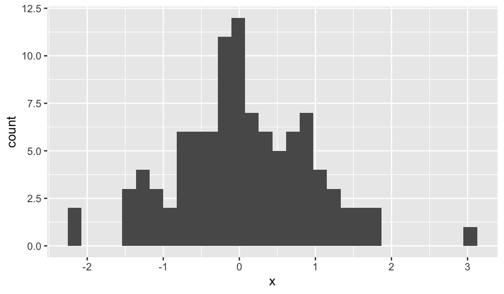

```r
d <- data.frame(x = rnorm(100))
ggplot(data = d) +
  geom_histogram(aes(x = x), bins = 30)
```

Hoy no hay que entender esas líneas. Hay que ver que **funcionan**.

**Nota**

`rnorm()` genera números al azar, así que tu histograma no será idéntico al de nadie más. Para que sí lo sea, se fija la semilla del generador:

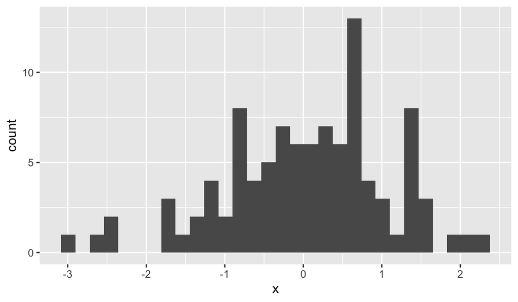

```r
set.seed(42)
d <- data.frame(x = rnorm(100))
ggplot(data = d) +
  geom_histogram(aes(x = x), bins = 30)
```

`set.seed()` no entra en el curso, pero es la diferencia entre un análisis que se puede reproducir y uno que no.

## 4. Asignación y nombres

```r
x <- 4
x
```

```
[1] 4
```

Asignar **no imprime**. Por eso hace falta la segunda línea.

```r
x <- 5 # el operador de R
y <- 10 # se lee "y recibe 10"
x + y
```

```
[1] 15
```

### El truco del número

```r
truco <- function(n) ((n * 5 + 1) * 2 - 12) / 10 - n

truco(7)
```

```
[1] -1
```

```r
truco(-3)
```

```
[1] -1
```

```r
truco(1000)
```

```
[1] -1
```

Siempre da `-1`, porque el número que pensaste se cancela:

$$\frac{(5n + 1)\cdot 2 - 12}{10} - n = \frac{10n - 10}{10} - n = -1$$

### Nombres que dicen algo

```r
# Se entiende hoy y dentro de un mes
casos_confirmados <- 125
poblacion_riesgo <- 5000
tasa_incidencia <- (casos_confirmados / poblacion_riesgo) * 1000
tasa_incidencia
```

```
[1] 25
```

```r
# Se entiende hoy
a <- 125
b <- 5000
c <- (a / b) * 1000
c
```

```
[1] 25
```

El segundo bloque funciona y está mudo. Y hay algo peor: acabas de crear un objeto llamado `c`, que es el nombre de la función más usada de la sesión 02.

```r
# La función sigue existiendo: R distingue objetos de funciones por contexto
c(1, 2, 3)
```

```
[1] 1 2 3
```

```r
# Pero conviene no acostumbrarse. Se limpia:
rm(c)
```

**Advertencia**

Que R sepa distinguirlos no significa que quien lea tu código lo haga. La regla del curso es no usar como nombre de variable nada que ya sea una función: `c`, `t`, `data`, `df`, `mean`, `sum`.

## 5. El caso: indicadores epidemiológicos

```r
casos_confirmados <- 125 # casos nuevos
poblacion_riesgo <- 5000 # personas en riesgo
muertes <- 8 # defunciones entre los casos
casos_totales <- 200 # todos los casos de la enfermedad

tasa_incidencia <- (casos_confirmados / poblacion_riesgo) * 1000
prevalencia <- (casos_totales / poblacion_riesgo) * 100
tasa_letalidad <- (muertes / casos_totales) * 100

tasa_incidencia
```

```
[1] 25
```

```r
prevalencia
```

```
[1] 4
```

```r
tasa_letalidad
```

```
[1] 4
```

`prevalencia` y `tasa_letalidad` valen 4 las dos, y no significan lo mismo: el 4 % de la población tiene la enfermedad, y el 4 % de los enfermos murió.

**TipEjercicio 2 · cambia los valores**

Asigna otros números de casos confirmados y de población en riesgo, y vuelve a calcular la tasa de incidencia.

**Pregunta:** ¿qué pasa si la población en riesgo crece y los casos confirmados se quedan igual?

### Respuesta

```r
casos_confirmados <- 125
poblacion_riesgo <- 20000 # cuatro veces más población
tasa_incidencia <- (casos_confirmados / poblacion_riesgo) * 1000
tasa_incidencia # 6.25 en vez de 25
```

La tasa **baja**: los mismos casos repartidos entre más gente. Por eso una tasa sin su denominador no dice nada.

```r
casos_confirmados <- 125
poblacion_riesgo <- 20000
(casos_confirmados / poblacion_riesgo) * 1000
```

```
[1] 6.25
```

**TipEjercicio 3 · dos poblaciones**

Asigna valores para dos poblaciones distintas —`poblacion_riesgo1` y `poblacion_riesgo2`—, calcula la tasa de incidencia en las dos y compáralas.

**Pregunta:** ¿cuál tiene mayor riesgo relativo?

### Respuesta

```r
casos1 <- 125
poblacion_riesgo1 <- 5000
casos2 <- 300
poblacion_riesgo2 <- 20000

ti1 <- (casos1 / poblacion_riesgo1) * 1000 # 25
ti2 <- (casos2 / poblacion_riesgo2) * 1000 # 15

ti1 > ti2 # TRUE: la primera población tiene mayor incidencia
```

Aunque la segunda tiene **más casos en términos absolutos**, su incidencia es menor porque la población en riesgo es cuatro veces mayor.

```r
casos1 <- 125
poblacion_riesgo1 <- 5000
casos2 <- 300
poblacion_riesgo2 <- 20000

ti1 <- (casos1 / poblacion_riesgo1) * 1000
ti2 <- (casos2 / poblacion_riesgo2) * 1000

ti1
```

```
[1] 25
```

```r
ti2
```

```
[1] 15
```

```r
ti1 > ti2
```

```
[1] TRUE
```

**Importante**

## Anexo · las prácticas de clase, con su respuesta

Todo lo que se teclea en las diapositivas `▸`, en orden y ejecutado. Sirve para repasar, y para quien faltó a una sesión.

### Parte A · la calculadora

```r
17 * 23
```

```
[1] 391
```

```r
2^10
```

```
[1] 1024
```

```r
144 %% 12 # ¿cuánto sobra al dividir?
```

```
[1] 0
```

```r
144 %% 12 == 0 # entonces sí es divisible
```

```
[1] TRUE
```

```r
125 / 5000
```

```
[1] 0.025
```

`%%` devuelve el resto. Si el resto es cero, la división es exacta.

### Parte A · los atajos

```r
2^20
```

```
[1] 1048576
```

```r
sum(1:10)
```

```
[1] 55
```

`1:10` son los números del 1 al 10, y `sum()` los suma: 55.

### Parte A · encuentra la función

```r
find("lowess")
```

```
[1] "package:stats"
```

```r
length(apropos("median")) # cuántas hay depende de lo que tengas cargado
```

```
[1] 3
```

```r
round(3.14159, digits = 2)
```

```
[1] 3.14
```

```r
round(3.14159, digits = 4)
```

```
[1] 3.1416
```

### Parte B · tus primeras variables

```r
casos <- 125
poblacion <- 5000
proporcion <- casos / poblacion

proporcion
```

```
[1] 0.025
```

Y para ver qué existe en el entorno sin imprimir nada:

```r
ls()
```

```
 [1] "a"                 "b"                 "casos"
 [4] "casos_confirmados" "casos_totales"     "casos1"
 [7] "casos2"            "d"                 "muertes"
[10] "poblacion"         "poblacion_riesgo"  "poblacion_riesgo1"
[13] "poblacion_riesgo2" "prevalencia"       "proporcion"
[16] "tasa_incidencia"   "tasa_letalidad"    "ti1"
[19] "ti2"               "truco"             "x"
[22] "y"
```

### Parte B · ¿cuáles son nombres válidos?

Los que funcionan:

```r
casos_2024 <- 1
.casos <- 1
tasa.incidencia <- 1
poblacion <- 1
c(casos_2024, .casos, tasa.incidencia, poblacion)
```

```
[1] 1 1 1 1
```

Los que **no**. Van comentados porque impiden que el archivo corra: pruébalos en la consola uno a uno.

```r
2024_casos <- 1 # Error: unexpected symbol
_casos <- 1 # Error: unexpected input
```

Y el que funciona y es mala idea:

```r
población <- 1 # corre aquí, rompe al abrir el archivo en otra computadora
población
```

```
[1] 1
```

### Parte B · escríbela tú, y cambia los valores

```r
casos_confirmados <- 125
poblacion_riesgo <- 5000
tasa_incidencia <- (casos_confirmados / poblacion_riesgo) * 1000
tasa_incidencia
```

```
[1] 25
```

Con cuatro veces más población y los mismos casos:

```r
poblacion_riesgo <- 20000
(casos_confirmados / poblacion_riesgo) * 1000
```

```
[1] 6.25
```

La tasa baja de 25 a 6.25. Los mismos casos, repartidos entre más gente.

### Parte B · el caso completo

```r
casos_confirmados <- 125 # casos nuevos
poblacion_riesgo <- 5000 # personas en riesgo
muertes <- 8 # defunciones entre los casos
casos_totales <- 200 # todos los casos

tasa_incidencia <- (casos_confirmados / poblacion_riesgo) * 1000
prevalencia <- (casos_totales / poblacion_riesgo) * 100
tasa_letalidad <- (muertes / casos_totales) * 100

c(tasa_incidencia, prevalencia, tasa_letalidad)
```

```
[1] 25  4  4
```

**Si cambias las muertes**, solo se mueve la letalidad:

```r
muertes <- 20
c(
  incidencia = (casos_confirmados / poblacion_riesgo) * 1000,
  prevalencia = (casos_totales / poblacion_riesgo) * 100,
  letalidad = (muertes / casos_totales) * 100
)
```

```
 incidencia prevalencia   letalidad
         25           4          10
```

**Si cambias la población**, se mueven la incidencia y la prevalencia, pero no la letalidad: su denominador son los casos, no la población.

```r
muertes <- 8
poblacion_riesgo <- 10000
c(
  incidencia = (casos_confirmados / poblacion_riesgo) * 1000,
  prevalencia = (casos_totales / poblacion_riesgo) * 100,
  letalidad = (muertes / casos_totales) * 100
)
```

```
 incidencia prevalencia   letalidad
       12.5         2.0         4.0
```

### Ejercicio 1 · dos municipios

```r
casos_a <- 125
poblacion_a <- 5000
casos_b <- 300
poblacion_b <- 20000

ti_a <- (casos_a / poblacion_a) * 1000
ti_b <- (casos_b / poblacion_b) * 1000

c(A = ti_a, B = ti_b)
```

```
 A  B
25 15
```

```r
ti_a > ti_b
```

```
[1] TRUE
```

**Importante**

El municipio B tiene **más del doble de casos** y **menos incidencia**, porque su población es cuatro veces mayor. Una cifra absoluta sin su denominador no dice nada.

### Ejercicio 3 · ¿qué está mal aquí?

```r
Casos <- 125
poblacion <- 5000
tasa <- casos / poblacion * 1000
```

Falla porque `Casos` con mayúscula y `casos` en minúscula son **dos variables distintas**, y la segunda no existe todavía en esa línea.